# Assignment 4

Griffin J. Lane

October 10, 2017

## 1.

### a. Install the fivethirtyeight package.

```r
#if not insta
#install.packages("fivethirtyeight")
library(fivethirtyeight)
```

### b. In the listing of Data sets in package ‘fivethirtyeight,’ assign the eighteenth data set to an object ‘df.’

```r
##This will give us website with a link to an R code snippet to get all the datasets
##It is commented out in order for .rmd to compile
#browseVignettes(package = "fivethirtyeight")

###It was possible to count to 18 but, this useful snippet was in the help docs for fivethirtyeight
## ---- message=FALSE, warning=FALSE, echo=FALSE---------------------------
library(fivethirtyeight)
# tidyverse includes ggplot2, tibble, tidyr, readr, purrr, dplyr:
library(tidyverse)
library(knitr)

datasets.538 <- read_csv("https://goo.gl/OT8iHa") %>%
  filter(!is.na(DATAFRAME_NAME)) %>%
  mutate(DATAFRAME_NAME = paste("`", DATAFRAME_NAME, "`", sep="")) %>%
  transmute(
    `Data Frame Name` = DATAFRAME_NAME,
    `Article Title` = ARTICLE_TITLE,
    `Filed Under` = ARTICLE_FILED_UNDER,
    `Author 1` = ARTICLE_AUTHOR_1,
    `Author 2` = ARTICLE_AUTHOR_2,
    `Author 3` = ARTICLE_AUTHOR_3,
    Date = ARTICLE_DATE,
    URL = ARTICLE_URL
  ) %>%
  arrange(`Data Frame Name`)
#kable(datasets)

##NOTE: I AM USING 16, NOT 18, DUE TO THE TWO MISSING DATA SETS
##US_births_2000_2014   and   US_births_1994_2003
##From the csv URL provided on the github account
##This gives us the name of the data frame
df.name <- datasets.538[16,which(colnames(datasets.538)=="Data Frame Name")]
df.name#$`Data Frame Name` #uncomment the tail to get a plain string
```

```
## # A tibble: 1 x 1
##        `Data Frame Name`
##                    <chr>
## 1 `college_recent_grads`
```

```r
##The readme mentioned that the sets were "lazy loaded"
df <- fivethirtyeight::college_recent_grads

##Note that if counted by hand from the table received with:
#    data(package = "fivethirtyeight")
#the dataset is different from what is recommended however at: http://127.0.0.1:10387/library/fivethirtyeight/doc/fivethirtyeight.Rmd
#That would return the comma survey dataset instead
```

### c. Use a more detailed list of the data sets to write out the URL in a comment to the related news story.

```r
#This is the URL related to the news story
df.URL <- datasets.538[16,which(colnames(datasets.538)=="URL")]
df.URL
```

```
## # A tibble: 1 x 1
##                                                                           URL
##                                                                         <chr>
## 1 http://fivethirtyeight.com/features/the-economic-guide-to-picking-a-college
```

```r
##Or all can be browsed via:
#vignette("fivethirtyeight", package = "fivethirtyeight")
```

### d. Using R command(s), give the dimensions and column names of this data frame.

```r
dim(df)
```

```
## [1] 173  21
```

```r
colnames(df) #or just: names(df)
```

```
##  [1] "rank"                        "major_code"
##  [3] "major"                       "major_category"
##  [5] "total"                       "sample_size"
##  [7] "men"                         "women"
##  [9] "sharewomen"                  "employed"
## [11] "employed_fulltime"           "employed_parttime"
## [13] "employed_fulltime_yearround" "unemployed"
## [15] "unemployment_rate"           "p25th"
## [17] "median"                      "p75th"
## [19] "college_jobs"                "non_college_jobs"
## [21] "low_wage_jobs"
```

## 2.

### a. Write an R command that gives you the column names of the data frame. Right after that, write one that counts the number of columns but not rows.

```r
GetNames <- function(dataFrame){
  colnames(dataFrame)
}

GetNames(df)
```

```
##  [1] "rank"                        "major_code"
##  [3] "major"                       "major_category"
##  [5] "total"                       "sample_size"
##  [7] "men"                         "women"
##  [9] "sharewomen"                  "employed"
## [11] "employed_fulltime"           "employed_parttime"
## [13] "employed_fulltime_yearround" "unemployed"
## [15] "unemployment_rate"           "p25th"
## [17] "median"                      "p75th"
## [19] "college_jobs"                "non_college_jobs"
## [21] "low_wage_jobs"
```

```r
GetColumnCount <- function(dataFrame){
  length(dataFrame) #no need to get fancy
}

GetColumnCount(df)
```

```
## [1] 21
```

### b. Generate a count of each unique major_category in the data frame. I recommend using libraries to help. To be clear, this should look like a matrix or data frame containing the major_category and the frequency it occurs in the dataset. Assign it to major_count.

```r
#sets major_count to a sorted data frame with the major category and it's frequency
major_count <- table(df$major_category) #I opted for a table instead of a data.frame
##You could use this if you wanted a data.frame:
#major_count <- data.frame(sort(table(df$major_category), decreasing = TRUE))
#names(major_count) <- c("MajorCategory","Frequency")

head(major_count, 10)
```

```
##
## Agriculture & Natural Resources                            Arts
##                              10                               8
##          Biology & Life Science                        Business
##                              14                              13
##     Communications & Journalism         Computers & Mathematics
##                               4                              11
##                       Education                     Engineering
##                              16                              29
##                          Health       Humanities & Liberal Arts
##                              12                              15
```

### c. To make things easier to read, put par(las=2) before your plot to make the text perpendicular to the axis. Make a barplot of major_count. Make sure to label the title with something informative (check the vignette if you need), label the x and y axis, and make it any color other than grey. Assign the major_category labels to their respective bar. Flip the barplot horizontally so that bars extend to the right, not upward. All of these options can be done in a single pass of barplot().

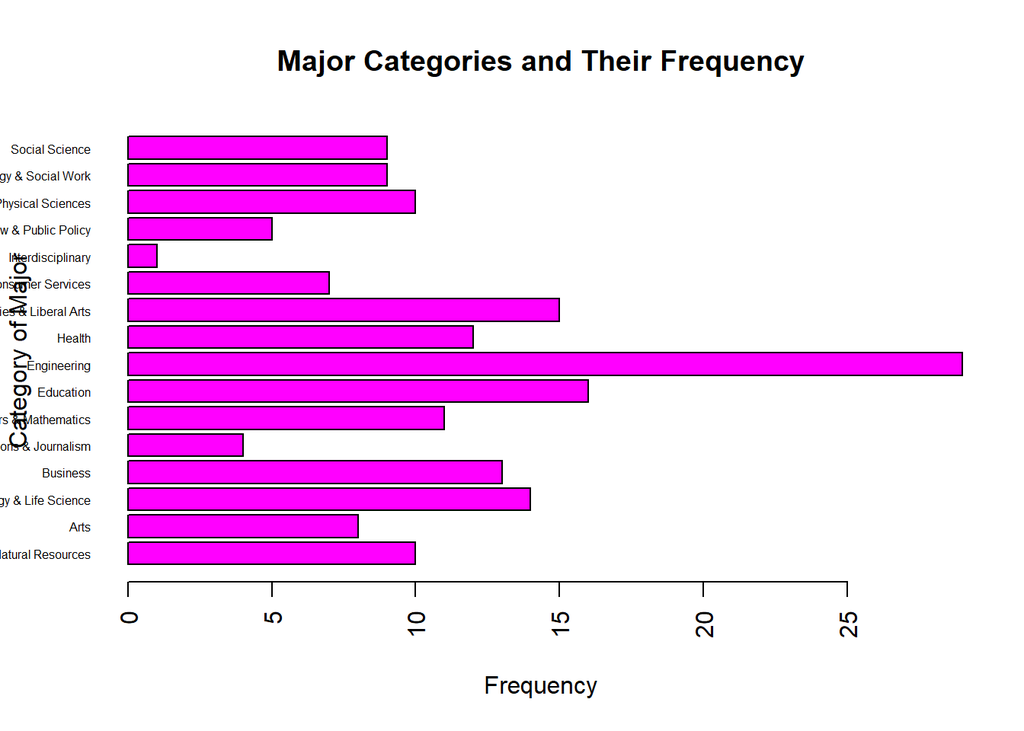

```r
par(las=2, ylab("DERPGASM"))
barplot(major_count, xlab = "Frequency", ylab = "Category of Major",main = "Major Categories and Their Frequency", col = "magenta", horiz = TRUE, cex.names = .5)
```

### d. Write the fivethirtyeight data to a csv file. Make sure that it does not have row labels.

```r
write.csv2(df, "RecentCollegeGradData.csv", row.names = FALSE)
```

## 3.

### a. Start a new repository on GitHub for your SMU MSDS homework. On your local device, make sure there is a directory for Homework at the minimum; you are welcome to add whatever you would like to this repo in addition to your requirements here.

```
#Repository has been pushed and committed via CMD line
```